# Basic graphics with tidy data, or: why starting tidy makes life in R palatable

Elizabeth Wickes, wickes1@illinois.edu, @elliewix

## Spreadsheet activity

Handout for the “Creating Tidy Data” workshop of the 2016 Midwest Data Librarian Symposium (MDLS). GitHub Repository: https://github.com/elliewix/but-i-just-want-to-make-a-graph

Open up the Excel file included within the GitHub repository. Take a few moments to explore it, the data included, structure, etc. Now, try to think about how you could reorganize it into a single data file. Work with 1-2 people sitting next to you. Determine what the new headers should be and write them down below.

Create a new tab and begin recreating the new data file if you have time remaining.

## R graphing activity

You should follow along in RStudio with these commands. You will be using a data file called `cleanedsurvey.csv` located within the GitHub repository.

### Load the library

You should have installed this with `install.packages("ggplot2")`. You call `library()` with the module name, without quotes, to load the library.

```r
library(ggplot2)
```

### Load the data

Use Tools -> Import Dataset -> From text file…

Select the files, and accept all the default options in the wizard. You can play around with these options and view the changes in the preview box.

```r
cleanedsurvey <- read.csv("cleanedsurvey.csv")
```

This creates an object in memory, called `cleanedsurvey`, that represents the data.frame containing the data.

### Make a basic histogram

This will be using ggplot2 to create a histogram. They usually start with a `ggplot()` statement that declares where the data frame is, then you use `+` to add graphic elements to the plot. You can layer these elements as desired.

You can see in the code below that we are declaring `data = cleanedsurvey` in `ggplot()`, but not selecting any of the data columns yet. Just providing the data frame.

`+` then adds a `geom_histogram()` graphical layer, which is a histogram. We tell it that we want `x = Weight`. `Weight` is the column name without quotes. The case must also match what appears in the data.frame it is contained within. There are many types of graphical elements (http://docs.ggplot2.org/current/) within the ggplot2 library.

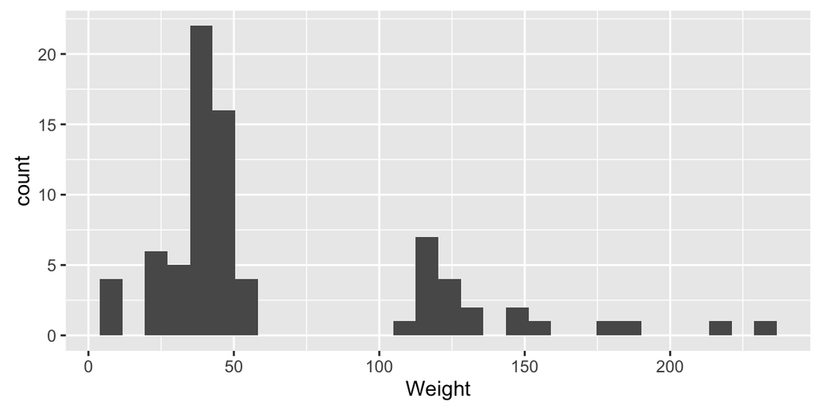

```r
ggplot(data = cleanedsurvey) + geom_histogram(aes(x = Weight))
```

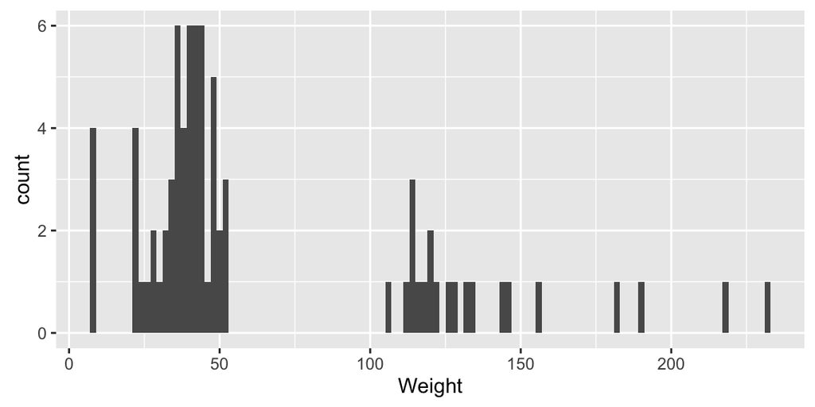

```r
ggplot(data = cleanedsurvey) + geom_histogram(aes(x = Weight), binwidth = 2)
```

### Now you

- Change some of the binwidth values to find the right balance for the data you are looking at
- Change the `x =` value to other columns and see what works and what doesn’t.
- Which columns worked? Which columns didn’t?
- What sort of errors did you get when you tried a column that didn’t work?
- What other sort of errors did you see in this process?

### Scatterplots and grouping

We can also use scatterplots to look at numerical data.

You can see that the syntax is already changing on us, but at least the x and y labels are showing our nice column headers.

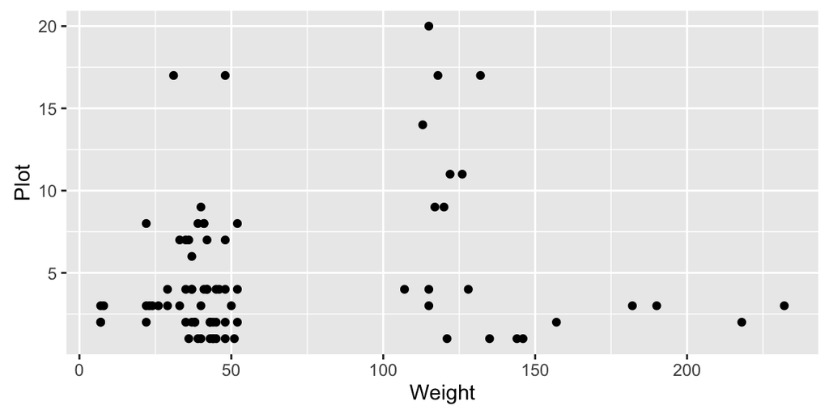

```r
ggplot(cleanedsurvey, aes(x = Weight, y = Plot)) + geom_point()
```

This is nice, but hard to tell a bit of what’s going on. Let’s group this in a few ways.

Because our code is getting long, we can save our basic ggplot code as a variable and reference it. We’re going to call our ggplot() object `p`. Nothing will happen when we first create `p` because we must call p to make it appear. Calling `p` alone will show a blank graph. We need to add our graphical element layer to see the actual chart.

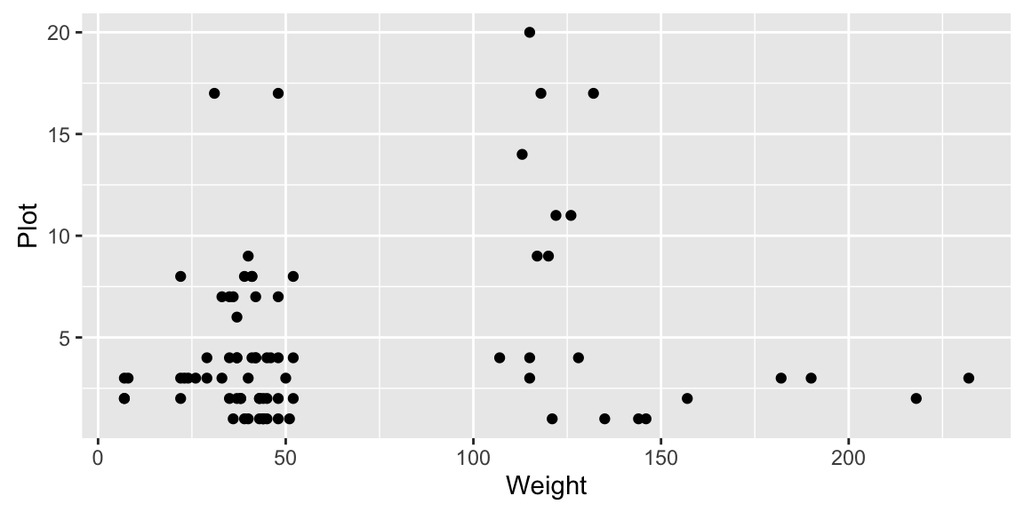

```r
p = ggplot(cleanedsurvey, aes(x = Weight, y = Plot)) # nothing will be plotted yet

p + geom_point() # the plot will appear when you evaluate it with a geometry element
```

Now we’re seeing the power of having our data already in tidy format. Because all our labels are in a single column, associated with each observation, we can just point R to that column and have nice labels and colors without too much work.

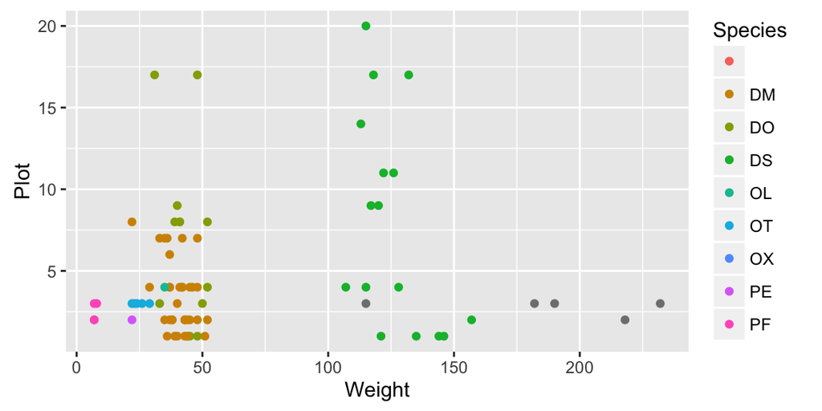

```r
p + geom_point(aes(color = Species)) # color by the Species column
```

### Now you

- Try changing the color variable to other columns within the data file.
- What worked? What didn’t?
- What were the errors that you encountered?